# Sztuczna inteligencja - Lista 4

## Mikołaj Kamiński 280596

```python
import pandas as pd
from sklearn.impute import SimpleImputer
from sklearn.model_selection import train_test_split
from sklearn.pipeline import Pipeline
from sklearn.compose import ColumnTransformer
from sklearn.preprocessing import StandardScaler, OneHotEncoder, MinMaxScaler
from sklearn.tree import DecisionTreeClassifier
from sklearn.metrics import accuracy_score, precision_score, recall_score, f1_score,classification_report
from sklearn.naive_bayes import GaussianNB
from sklearn.ensemble import RandomForestClassifier
from sklearn.model_selection import train_test_split, GridSearchCV
from sklearn.svm import SVC
import os
import glob
from pathlib import Path
from datetime import datetime
import seaborn as sns
import matplotlib.pyplot as plt
```

# Ładowanie i screening danych

Zaczynamy od załadowania danych do DataFrame oraz wyciągniecią kolumn potrzebnych w dalszej analizie.

```python
df = pd.read_csv("data/cirrhosis.csv")
valid_columns = [
    "Drug", "Age", "Sex", "Ascites", "Hepatomegaly", "Spiders",
    "Edema", "Bilirubin", "Cholesterol", "Albumin", "Copper",
    "Alk_Phos", "SGOT", "Tryglicerides", "Platelets",
    "Prothrombin", "Stage", "Status"
]
df = df[valid_columns]
print("Rozmiar dataframe", df.shape)
print("Przykładowe w dataframie")
print(df.head())
```

```
Rozmiar dataframe (418, 18)
Przykładowe w dataframie
              Drug    Age Sex Ascites Hepatomegaly Spiders Edema  Bilirubin  \
0  D-penicillamine  21464   F       Y            Y       Y     Y       14.5
1  D-penicillamine  20617   F       N            Y       Y     N        1.1
2  D-penicillamine  25594   M       N            N       N     S        1.4
3  D-penicillamine  19994   F       N            Y       Y     S        1.8
4          Placebo  13918   F       N            Y       Y     N        3.4

   Cholesterol  Albumin  Copper  Alk_Phos    SGOT  Tryglicerides  Platelets  \
0        261.0     2.60   156.0    1718.0  137.95          172.0      190.0
1        302.0     4.14    54.0    7394.8  113.52           88.0      221.0
2        176.0     3.48   210.0     516.0   96.10           55.0      151.0
3        244.0     2.54    64.0    6121.8   60.63           92.0      183.0
4        279.0     3.53   143.0     671.0  113.15           72.0      136.0

   Prothrombin  Stage Status
0         12.2    4.0      D
1         10.6    3.0      C
2         12.0    4.0      D
3         10.3    4.0      D
4         10.9    3.0     CL
```

```python
print(df.describe(include='all'))
```

```
                   Drug           Age  Sex Ascites Hepatomegaly Spiders Edema  \
count               312    418.000000  418     312          312     312   418
unique                2           NaN    2       2            2       2     3
top     D-penicillamine           NaN    F       N            Y       N     N
freq                158           NaN  374     288          160     222   354
mean                NaN  18533.351675  NaN     NaN          NaN     NaN   NaN
std                 NaN   3815.845055  NaN     NaN          NaN     NaN   NaN
min                 NaN   9598.000000  NaN     NaN          NaN     NaN   NaN
25%                 NaN  15644.500000  NaN     NaN          NaN     NaN   NaN
50%                 NaN  18628.000000  NaN     NaN          NaN     NaN   NaN
75%                 NaN  21272.500000  NaN     NaN          NaN     NaN   NaN
max                 NaN  28650.000000  NaN     NaN          NaN     NaN   NaN

         Bilirubin  Cholesterol     Albumin      Copper      Alk_Phos  \
count   418.000000   284.000000  418.000000  310.000000    312.000000
unique         NaN          NaN         NaN         NaN           NaN
top            NaN          NaN         NaN         NaN           NaN
freq           NaN          NaN         NaN         NaN           NaN
mean      3.220813   369.510563    3.497440   97.648387   1982.655769
std       4.407506   231.944545    0.424972   85.613920   2140.388824
min       0.300000   120.000000    1.960000    4.000000    289.000000
25%       0.800000   249.500000    3.242500   41.250000    871.500000
50%       1.400000   309.500000    3.530000   73.000000   1259.000000
75%       3.400000   400.000000    3.770000  123.000000   1980.000000
max      28.000000  1775.000000    4.640000  588.000000  13862.400000

              SGOT  Tryglicerides   Platelets  Prothrombin       Stage Status
count   312.000000     282.000000  407.000000   416.000000  412.000000    418
unique         NaN            NaN         NaN          NaN         NaN      3
top            NaN            NaN         NaN          NaN         NaN      C
freq           NaN            NaN         NaN          NaN         NaN    232
mean    122.556346     124.702128  257.024570    10.731731    3.024272    NaN
std      56.699525      65.148639   98.325585     1.022000    0.882042    NaN
min      26.350000      33.000000   62.000000     9.000000    1.000000    NaN
25%      80.600000      84.250000  188.500000    10.000000    2.000000    NaN
50%     114.700000     108.000000  251.000000    10.600000    3.000000    NaN
75%     151.900000     151.000000  318.000000    11.100000    4.000000    NaN
max     457.250000     598.000000  721.000000    18.000000    4.000000    NaN
```

Analizując dane możemy zauważyć kilka ciekawych własności.

Prawie całość pacjentów w datasecie stanowią kobiety, co może obniżyć skuteczność modeli jeżeli chodzi o wyniki dla mężczyzn

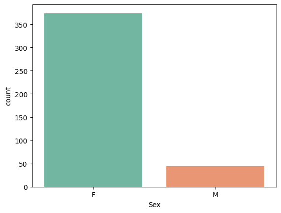

```python
ax = sns.countplot(data = df, x='Sex', hue="Sex", palette="Set2")
```

Zmienna docelowa jest wyraźnie niezbalansowana, isntnieje wyraźna przewaga klasy C nad stanami krytycznymi (D - śmierć, CL - przeszczep).

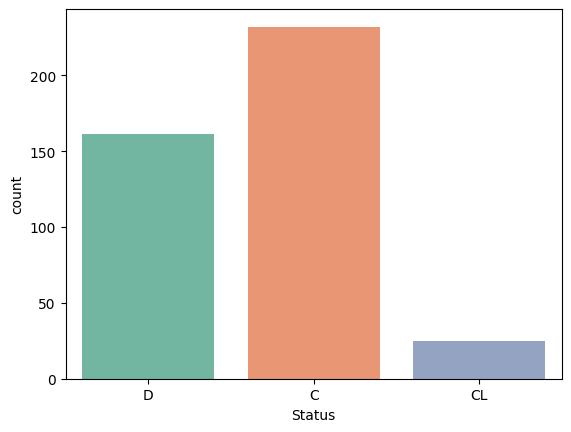

```python
ax = sns.countplot(data=df, x="Status",hue="Status", palette="Set2")
```

Większość miar związanych z wynikami krwi, posiada wielu otlierów. W skrajnych przypadkach wykorzystywane średniej zamiast mediany do uzupełniania danych może spowodować spadek skuteczności modelu.

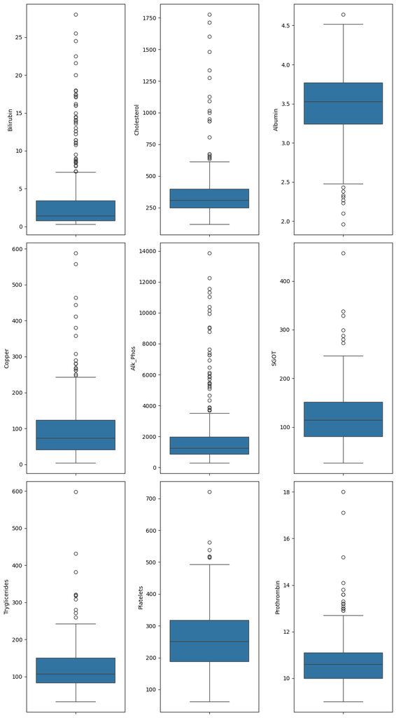

```python
metric_columns = [
     "Bilirubin", "Cholesterol", "Albumin", "Copper",
     "Alk_Phos", "SGOT", "Tryglicerides", "Platelets",
    "Prothrombin"
]
fig, axs = plt.subplots(3,3, figsize=(10, 18))
for i in range(9):
    rw = i //3
    cl = i % 3
    sns.boxplot(data=df, y=metric_columns[i], ax=axs[rw][cl])
plt.tight_layout()
plt.show()
```

Zbiór zawiera ponad 100 rekordów gdzie wybrakowane kolumny to aż 9/17. O ile dane z kilkoma wartościami wnoszą dużą wartość to dane które są tworzone zupełnie syntetycznie, mogą utrudniać sensowne trenowanie modelu i tworzyć szum. W ramach eksperymentu postanowaiłem utworzyc trzy zbiory: bazowy(brak zmian), średnio wyczysczony(usunięte tylko wiersze z 9 lub więcej nullami). agresywnie wyczyszczony(usunięto wszystkie wiersze z wartościami null)

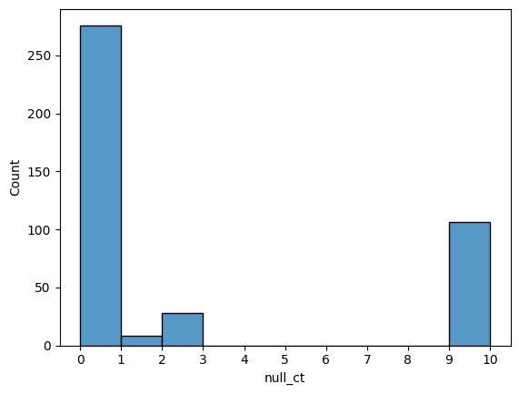

```python
from matplotlib.ticker import MaxNLocator

df['null_ct'] = (df.isna().apply(lambda x: x.sum(),  axis=1))
ax = sns.histplot(data=df['null_ct'], bins=10)
plt.xticks(range(int(df['null_ct'].min()), int(df['null_ct'].max()) + 1))
plt.show()
df =df.drop(columns='null_ct')
```

```python
df_cleaned = df.dropna(axis=0, thresh=10, inplace=False)
df_cleaned_more= df.dropna(axis=0, how='any', inplace=False)
dataframes = [df, df_cleaned, df_cleaned_more]
for dataF in dataframes:
    print(dataF.shape)
```

```
(418, 18)
(312, 18)
(276, 18)
```

Kolejnym etapem jest budowa Pipeline, który pozwoli na zautomatyzowaną transformację danych. Do optymalizacji hiperparametrów wykorzystano algorytm GridSearchCV, dzięki czemu wyłoniono zestaw parametrów maksymalizujący średni wynik dla metryki `f1_macro`. Metryka ta została wybrana ze względu na to, że jest znacznie bardziej miarodajna niż `accuracy` w przypadku niezbalansowanych zbiorów danych - model zgadujący ciągle C osiągnął by `accuracy` równe 55%. W przeciwieństwie do wariantów `f1_weighted` i `f1_micro`, uśrednianie makro traktuje każdą klasę równorzędnie, co zapobiega faworyzowaniu najliczniejszej grupy pacjentów

```python
def pipeline(df: pd.DataFrame, classifier, param_grid: dict) -> pd.DataFrame:
    X = df.drop(columns='Status')
    y = df['Status']
    X_train, X_test, y_train, y_test = train_test_split(X, y, test_size=0.2, random_state=42)

    men_only = X_test['Sex']=='M'
    X_test_men = X_test[men_only]
    y_test_men = y_test[men_only]

    num_features = ['Age', 'Bilirubin', 'Albumin', 'Copper', 'Alk_Phos', 'SGOT', 'Tryglicerides', 'Platelets', 'Prothrombin', 'Cholesterol', 'Stage']
    cat_features = ['Drug', 'Sex', 'Ascites', 'Hepatomegaly', 'Spiders', 'Edema']

    num_transformer = Pipeline(steps=[
        ('imputer', SimpleImputer(strategy='mean')),
        ('scales', StandardScaler())
    ])

    cat_transformer = Pipeline(steps=[
        ('imputer', SimpleImputer(strategy='most_frequent')),
        ('onehot', OneHotEncoder(handle_unknown='ignore'))
    ])

    preprocessor = ColumnTransformer(
    transformers=[
        ('num', num_transformer, num_features),
        ('cat', cat_transformer, cat_features)
    ])

    model_pipeline = Pipeline(steps=[
        ('preprocessor', preprocessor),
        ('classifier', classifier)
    ])

    grid_search = GridSearchCV(
        estimator=model_pipeline,
        param_grid=param_grid,
        cv=5,
        scoring='f1_macro',
        n_jobs=-1,
        verbose=3
    )

    grid_search.fit(X_train, y_train)

    best_model = grid_search.best_estimator_
    predictions = best_model.predict(X_test)
    predictions_men = best_model.predict(X_test_men)

    acc = accuracy_score(y_test, predictions)
    prec = precision_score(y_test, predictions, average='weighted', zero_division=0)
    rec = recall_score(y_test, predictions, average='weighted', zero_division=0)
    f1 = f1_score(y_test, predictions, average='weighted', zero_division=0)

    model_name = classifier.__class__.__name__
    parameters = grid_search.best_params_

    best_num_strat = parameters.get('preprocessor__num__imputer__strategy', 'Nie testowano w Grid')
    best_cat_strat = parameters.get('preprocessor__cat__imputer__strategy', 'Nie testowano w Grid')

    results = pd.DataFrame({
        'Classifier': [model_name],
        'Brak_Num_Best': [best_num_strat],
        'Brak_Cat_Best': [best_cat_strat],
        'Accuracy': [round(acc, 4)],
        'Precision': [round(prec, 4)],
        'Recall': [round(rec, 4)],
        'F1_Score': [round(f1, 4)],
        'Hiperparametry': [str(parameters)]
    })
    report1 = classification_report(y_test, predictions, zero_division=0)
    report2 = classification_report(y_test_men, predictions_men, zero_division=0)



    return results, report1, report2
```

W swoich testach wykorzystałem 4 rodzaje klasyfikatorów:

## Gaussian Naive Bayes

Algorytm probabilistyczny oparty na twierdzeniu Bayesa. Nazywany jest „naiwnym”, ponieważ opiera się na silnym założeniu o wzajemnej niezależności wszystkich cech (zmiennych objaśniających) względem zmiennej docelowej. W tym badaniu wykorzystano wariant Gaussa (GaussianNB), który zakłada, że zmienne numeryczne charakteryzują się rozkładem normalnym. Mimo swojej prostoty i "naiwnego" założenia, model ten jest niezwykle szybki, dobrze radzi sobie z brakami w danych i często stanowi doskonały punkt odniesienia (baseline) dla bardziej złożonych algorytmów.

## Decision Tree Classifier

Jest to model o strukturze grafu skierowanego (przypominającego drzewo lub schemat blokowy), w którym węzły wewnętrzne reprezentują testy na poszczególnych cechach, gałęzie to wyniki tych testów, a liście to ostateczne etykiety klas (w tym przypadku status pacjenta). Algorytm buduje drzewo, iteracyjnie dzieląc zbiór danych w taki sposób, aby maksymalizować zysk informacyjny lub minimalizować zanieczyszczenie. Główną zaletą drzew decyzyjnych jest ich wysoka interpretowalność, jednak mają one silną tendencję do przeuczenia, przez co konieczne jest stosowanie pruningu, np. poprzez ograniczanie maksymalnej głębokości drzewa.

## Random Forest Classifier

Las losowy to zaawansowany algorytm zespołowy, który stanowi rozwinięcie koncepcji drzew decyzyjnych i skutecznie rozwiązuje ich problem przeuczenia. Model ten buduje wiele niezależnych drzew decyzyjnych na podstawie losowych podzbiorów danych treningowych oraz przy użyciu losowych podzbiorów cech podczas każdego podziału węzła. Ostateczna predykcja lasu losowego jest wynikiem głosowania większościowego wszystkich wygenerowanych drzew. Dzięki temu podejściu model charakteryzuje się znacznie wyższą dokładnością, stabilnością oraz odpornością na szum w danych.

## Support Vector Machine - SVM

Jeden z najpotężniejszych algorytmów klasyfikacyjnych. Jego głównym celem jest znalezienie optymalnej hiperpłaszczyzny w wielowymiarowej przestrzeni cech, która oddziela od siebie poszczególne klasy z maksymalnym możliwym marginesem (odległością od najbliższych punktów danych, zwanych wektorami nośnymi). W podstawowej wersji SVM służy do klasyfikacji liniowej, jednak dzięki zastosowaniu tzw.kernel trick – polegającej na transformacji danych do przestrzeni o wyższym wymiarze – potrafi niezwykle skutecznie rozwiązywać problemy, w których dane nie są liniowo separowalne.

```python
save_path = Path(os.getcwd()) / "test_result"
now = "20260525_002030"
```

```python
tree_param = {
    'preprocessor__num__imputer__strategy': ['mean', 'median'],
    'preprocessor__cat__imputer__strategy': ['most_frequent', 'constant'],
    'classifier__max_depth': [3, 5, 10, None],
    'classifier__min_samples_split': [2, 10],
    'preprocessor__num__scales': ['passthrough', StandardScaler(), MinMaxScaler()]
}

bayes_param = {
    'preprocessor__num__imputer__strategy': ['mean', 'median'],
    'preprocessor__cat__imputer__strategy': ['most_frequent', 'constant'],
    'classifier__var_smoothing': [1e-9, 1e-8, 1e-7],
    'preprocessor__num__scales': ['passthrough', StandardScaler(), MinMaxScaler()]
}

forest_param = {
    'preprocessor__num__imputer__strategy': ['mean', 'median'],
    'preprocessor__cat__imputer__strategy': ['most_frequent', 'constant'],
    'classifier__n_estimators': [50, 100, 200],
    'classifier__max_depth': [None, 5, 10],
    'classifier__min_samples_split': [2, 10],
    'preprocessor__num__scales': ['passthrough', StandardScaler(), MinMaxScaler()],
}

svm_param = {
    'preprocessor__num__imputer__strategy': ['mean', 'median'],
    'preprocessor__cat__imputer__strategy': ['most_frequent', 'constant'],
    'classifier__C': [0.1, 1, 10],
    'classifier__kernel': ['linear', 'rbf'],
    'classifier__gamma': ['scale', 'auto'],
    'preprocessor__num__scales': ['passthrough', StandardScaler(), MinMaxScaler()]
}

model_params = [
    (DecisionTreeClassifier(random_state=42), tree_param),
    (GaussianNB(), bayes_param),
    (RandomForestClassifier(random_state=42), forest_param),
    (SVC(), svm_param)
]

test_res = pd.DataFrame()

# Prepare separate report files per dataframe kind
reports_dir = Path(os.getcwd()) / "test_result" / "reports"
os.makedirs(reports_dir, exist_ok=True)
# now = datetime.now().strftime('%Y%m%d_%H%M%S')
report_files = {
    'base': reports_dir / f"classification_reports_base_{now}.txt",
    'medium_cleaned': reports_dir / f"classification_reports_medium_cleaned_{now}.txt",
    'hard_cleaned': reports_dir / f"classification_reports_hard_cleaned_{now}.txt",
}
# create files with headers
for k, p in report_files.items():
    with open(p, 'w', encoding='utf-8') as f:
        f.write(f"Classification reports for {k} generated on {datetime.now().isoformat()}\n\n")

for clss, params in model_params:
    for num, dataframe in enumerate(dataframes, 0):
        res, report_overall, report_men = pipeline(df=dataframe, classifier=clss, param_grid=params)
        if num == 0:
            df_kind = 'base'
        elif num == 1:
            df_kind = 'medium_cleaned'
        elif num == 2:
            df_kind = 'hard_cleaned'
        else:
            df_kind = ''
        res['df_kind'] = df_kind
        test_res = pd.concat([test_res, res], ignore_index=True)

        model_name = res['Classifier'].iloc[0] if 'Classifier' in res.columns else clss.__class__.__name__
        hiperparams = res['Hiperparametry'].iloc[0] if 'Hiperparametry' in res.columns else ''

        # append this model's reports to the corresponding file based on dataframe kind
        target_file = report_files.get(df_kind, reports_dir / report_files[df_kind])
        with open(target_file, 'a', encoding='utf-8') as f:
            f.write('=== ' + model_name + ' - ' + df_kind + ' ===\n')
            f.write('Hiperparametry: ' + str(hiperparams) + '\n\n')
            f.write('--- WYNIKI DLA CAŁEGO ZBIORU TESTOWEGO ---\n')
            f.write(report_overall + '\n')
            f.write('--- WYNIKI TYLKO DLA MĘŻCZYZN ---\n')
            f.write(report_men + '\n\n')


# Save res
os.makedirs(save_path, exist_ok=True)
test_res.to_csv(save_path / f"{datetime.now().strftime('%Y%m%d_%H%M%S')}.csv", index=False)
```

# Analiza uzyskanych wyników

```python
save_path = Path(os.getcwd()) / "test_result"
proper_file = max(glob.glob(str(save_path)+"/*.csv"), key=os.path.getctime)
analysis_df = pd.read_csv(proper_file)
```

## 1. Metody uzupełniania danych

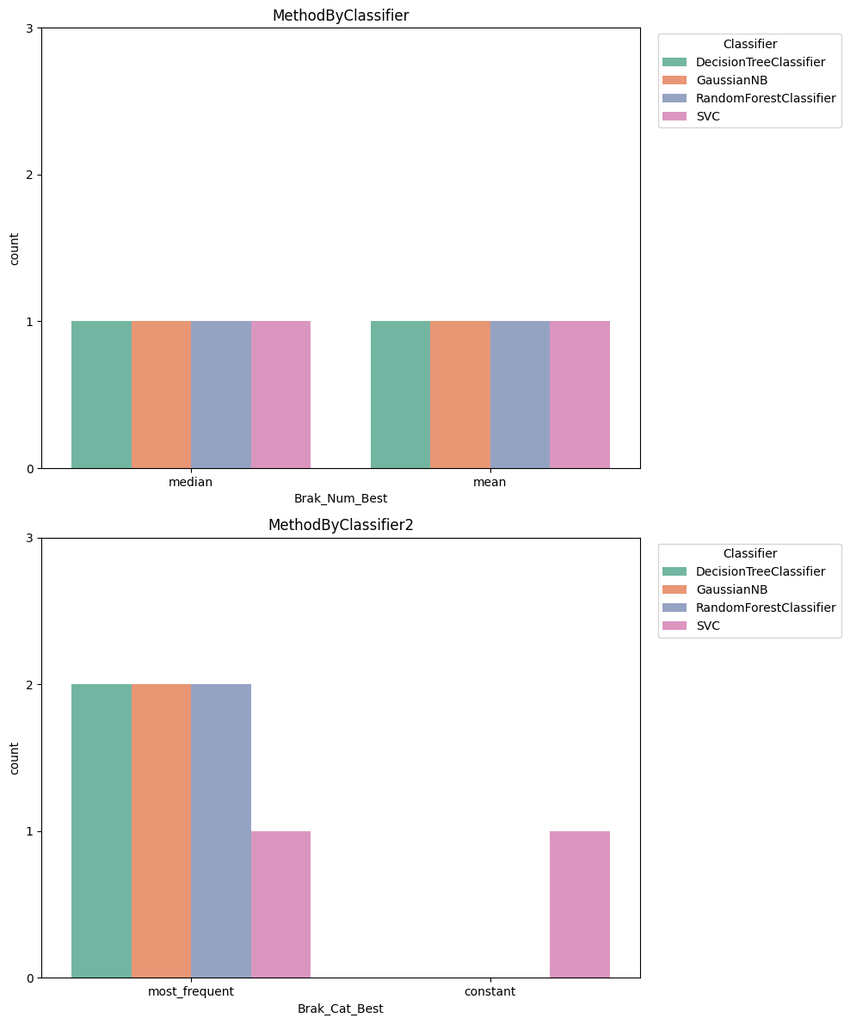

```python
def get_completion_method_by_dataframe(dataframe: pd.DataFrame, method_col: str, hue: str, title: str, ax=None):
    if ax is None:
        fig, ax = plt.subplots(figsize=(10, 6))
    sns.countplot(
        data=dataframe,
        x=method_col,
        hue=hue,
        palette="Set2",
        ax=ax
    )
    ax.set_title(title)
    ax.set_yticks([i for i in range(4)])
    ax.legend(title=hue.capitalize(), bbox_to_anchor=(1.02, 1), loc="upper left")
    return ax

fig, axes = plt.subplots(2, 1, figsize=(10, 12), sharey=True)
filtered = analysis_df.where(analysis_df['df_kind']!='hard_cleaned')

get_completion_method_by_dataframe(filtered, 'Brak_Num_Best', 'Classifier', 'MethodByClassifier', ax=axes[0])
get_completion_method_by_dataframe(filtered, 'Brak_Cat_Best', 'Classifier', 'MethodByClassifier2', ax=axes[1])

plt.tight_layout()
plt.show()
```

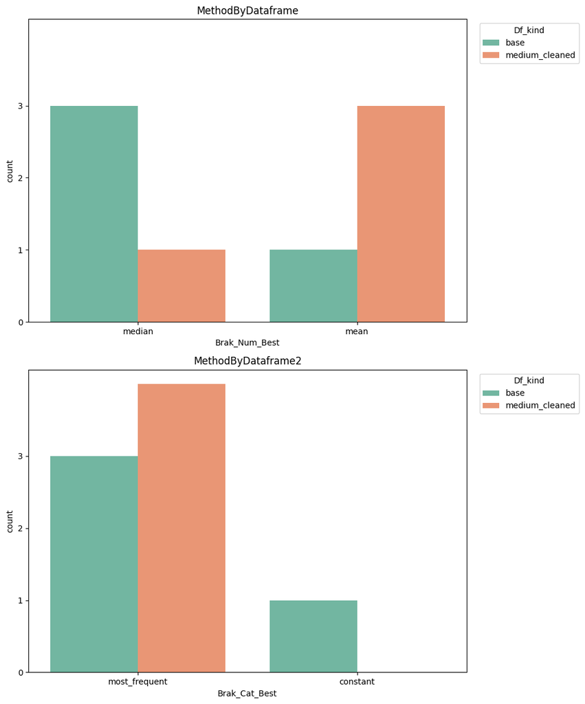

```python
fig, axes = plt.subplots(2, 1, figsize=(10, 12), sharey=True)

get_completion_method_by_dataframe(filtered, 'Brak_Num_Best', 'df_kind', 'MethodByDataframe', ax=axes[0])
get_completion_method_by_dataframe(filtered, 'Brak_Cat_Best', 'df_kind', 'MethodByDataframe2', ax=axes[1])

plt.tight_layout()
plt.show()
```

Ze zbioru zostały usunięte dane dotyczące uzupełniania danych w zbiorze kompletnym jako, że w zbiorze kompletnym metody uzupełniania danych nie mają żadnego znaczenia. Analizując wykresy możemy zauważyć, że większość modeli o najwyższym `f1` najczęściej występującą wartość do uzupełniania brakujących danych. O ile w przypadku podziału według klasyfikatora ciężko jest wyjąć konkretne wnioski o tyle w przypadku podziału według rodzaju użytego zbioru widzimy już znacznie ciekawszą zależność. Przy pełnym zbiorze najlepsze modele, korzystały z mediany do uzupełniania danych jednak dla średnio wyczyszczonego zbioru modele decydowały się prawie wyłącznie na średnią. Wstępna eksploracja danych oraz analiza statystyk sugerowała, że z uwagi na obecność silnych outlierów w wynikach badań krwi, najbezpieczniejszym i najskuteczniejszym wyborem powinna być mediana.

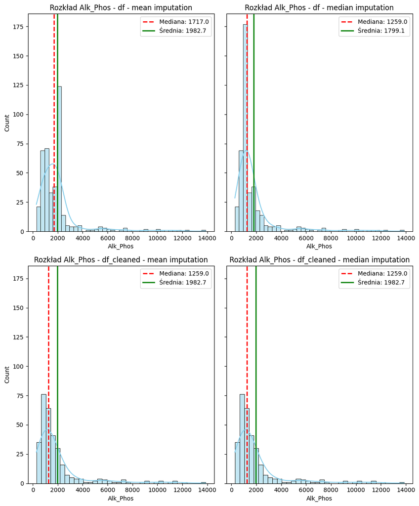

```python
metric_columns = [
    "Bilirubin", "Cholesterol", "Albumin", "Copper", "Alk_Phos",
    "SGOT", "Tryglicerides", "Platelets", "Prothrombin"
]
col = metric_columns[4]

df_mean_filled = df.copy()
df_median_filled = df.copy()
df_mean_filled_med = df_cleaned.copy()
df_median_filled_med = df_cleaned.copy()

df_mean_filled[col] = df_mean_filled[col].fillna(df_mean_filled[col].mean())
df_median_filled[col] = df_median_filled[col].fillna(df_median_filled[col].median())
df_mean_filled_med[col] = df_mean_filled_med[col].fillna(df_mean_filled_med[col].mean())
df_median_filled_med[col] = df_median_filled_med[col].fillna(df_median_filled_med[col].median())

fig, axs = plt.subplots(2,2, figsize=(10, 12), sharey=True)
plots = [
    (axs[0, 0], df_mean_filled, "df - mean imputation"),
    (axs[0, 1], df_median_filled, "df - median imputation"),
    (axs[1, 0], df_mean_filled_med, "df_cleaned - mean imputation"),
    (axs[1, 1], df_median_filled_med, "df_cleaned - median imputation"),
]

for ax, data, title in plots:
    sns.histplot(data[col].dropna(), kde=True, color="skyblue", ax=ax)
    ax.axvline(data[col].median(), color="red", linestyle="dashed", linewidth=2, label=f"Mediana: {data[col].median():.1f}")
    ax.axvline(data[col].mean(), color="green", linewidth=2, label=f"Średnia: {data[col].mean():.1f}")
    ax.set_title(f"Rozkład {col} - {title}")
    ax.legend()

plt.tight_layout()
plt.show()
```

## 2. Średnie wartości metryk wyniki względem rodzajów klasyfikatorów i zestawu danych

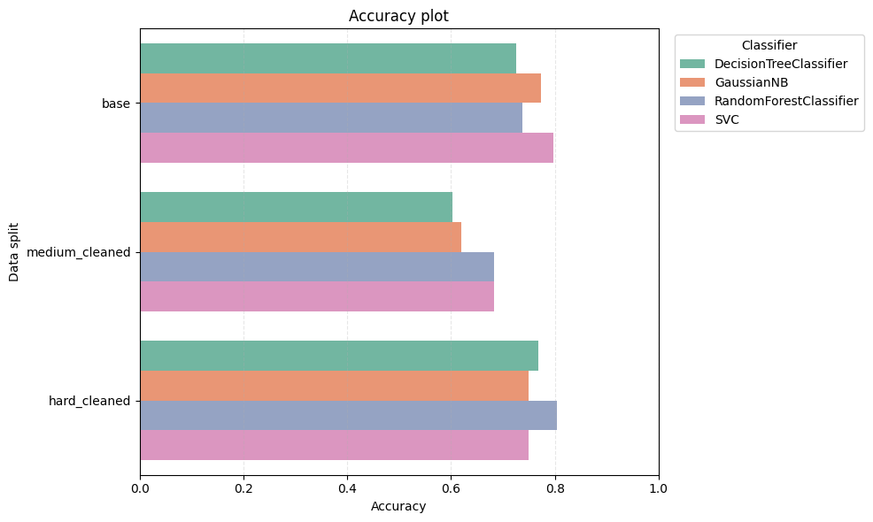

```python
def metric_byDataframe_byClassifier(dataframe: pd.DataFrame, metric_name:str, title: str,pallete: str):
    plt.figure(figsize=(10, 6))
    ax = sns.barplot(
        data=dataframe,
        x=metric_name,
        y="df_kind",
        hue="Classifier",
        orient="h",
        palette=pallete
    )
    ax.set_title(title)
    ax.set_xlabel("Accuracy")
    ax.set_ylabel("Data split")
    ax.set_xlim(0, 1)
    ax.legend(title="Classifier", bbox_to_anchor=(1.02, 1), loc="upper left")
    ax.grid(axis="x", linestyle="--", alpha=0.3)

    plt.tight_layout()
    plt.show()

metric_byDataframe_byClassifier(analysis_df, 'Accuracy', 'Accuracy plot', 'Set2')
```

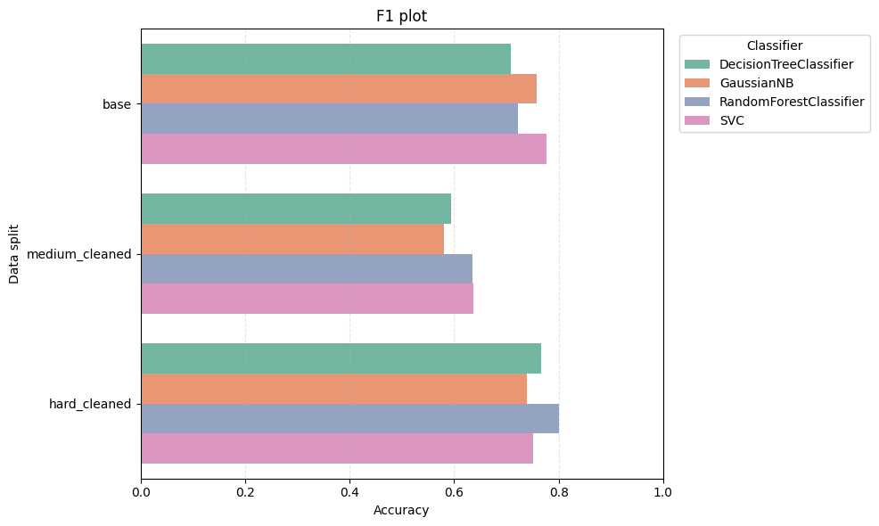

```python
metric_byDataframe_byClassifier(analysis_df, 'F1_Score', 'F1 plot', 'Set2')
```

Osiągnięte wyniki prezentują ciekawe własności. Zarówno `Accurtacy` jak i `F1 score` najwyższe wartości osiągają dla rygorystycznie wyczyszczonego datasetu. Tak dobre wyniki są spowodowane tym, że modele uczone są na zupełnie kompletnym zbiorze. Nie znaczy to jednak o sile modelu tylko o jego przeuczeniu na małym zbiorze, więc jego użytecznośc w rzeczywistym środowisku nie była by zbyt, jako że braki w danych dotyczących badań są raczej standardem.

Zaskakująco wysokie, drugie miejsce na zbiorze bazowym zajął `Naiwny klasyfikator Bayesa` (GaussianNB, F1-score: 0.7573), którym zdeklasował bardziej zaawansowane modele oparte na drzewach. Wynika to z faktu, że sztuczna imputacja braków średnią lub medianą uwypukliła centralne wartości rozkładu, co idealnie wpisało się w założenie tego algorytmu o rozkładzie normalnym danych.

Z kolei zaawansowany `Random Forest`, mimo ogromnego potencjału, poradził sobie na zbiorze bazowym zauważalnie słabiej (F1-score: 0.7229). Wprowadzenie ogromnej liczby identycznych, sztucznych wartości (median) utrudniło algorytmom drzewiastym odnajdywanie optymalnych punktów podziału dla gałęzi. Moc Random Forest widać dopiero w ewaluacji na zbiorze hard_cleaned, gdzie w środowisku pozbawionym sztucznie łatanych luk informacyjnych, algorytm ten osiągnął najwyższy wynik w całym zestawieniu (F1-score: 0.8007), wyprzedzając SVC. Potwierdza to, że modele ensemble brylują na danych czystych, lecz w środowisku wysokiej niepewności i silnej imputacji ustępują stabilności `SVC`

Analizując uzyskane modele pod kątem rzeczywistego zastosowania faworytem wydaje się być klasyfikator `SVC` dla zbioru bazowego:

```
    SVC,median,constant,0.7976,0.7598,0.7976,0.7774,{'classifier__C': 10, 'classifier__gamma': 'scale', 'classifier__kernel': 'linear', 'preprocessor__cat__imputer__strategy': 'constant', 'preprocessor__num__imputer__strategy': 'median', 'preprocessor__num__scales': StandardScaler()},base
```

## 3. Porównanie SVC dla zbioru base i hard cleaned

```
=== SVC - base ===
Hiperparametry: {'classifier__C': 10, 'classifier__gamma': 'scale', 'classifier__kernel': 'linear', 'preprocessor__cat__imputer__strategy': 'constant', 'preprocessor__num__imputer__strategy': 'median', 'preprocessor__num__scales': StandardScaler()}

--- WYNIKI DLA CAŁEGO ZBIORU TESTOWEGO ---
              precision    recall  f1-score   support

           C       0.80      0.89      0.84        44
          CL       0.00      0.00      0.00         4
           D       0.80      0.78      0.79        36

    accuracy                           0.80        84
   macro avg       0.53      0.55      0.54        84
weighted avg       0.76      0.80      0.78        84

--- WYNIKI TYLKO DLA MĘŻCZYZN ---
              precision    recall  f1-score   support

           C       1.00      1.00      1.00         2
           D       1.00      1.00      1.00         5

    accuracy                           1.00         7
   macro avg       1.00      1.00      1.00         7
weighted avg       1.00      1.00      1.00         7
```

```
=== SVC - hard_cleaned ===
Hiperparametry: {'classifier__C': 10, 'classifier__gamma': 'scale', 'classifier__kernel': 'rbf', 'preprocessor__cat__imputer__strategy': 'most_frequent', 'preprocessor__num__imputer__strategy': 'mean', 'preprocessor__num__scales': MinMaxScaler()}

--- WYNIKI DLA CAŁEGO ZBIORU TESTOWEGO ---
              precision    recall  f1-score   support

           C       0.74      0.93      0.82        30
          CL       0.00      0.00      0.00         0
           D       0.88      0.54      0.67        26

    accuracy                           0.75        56
   macro avg       0.54      0.49      0.50        56
weighted avg       0.80      0.75      0.75        56

--- WYNIKI TYLKO DLA MĘŻCZYZN ---
              precision    recall  f1-score   support

           C       0.50      0.33      0.40         3
          CL       0.00      0.00      0.00         0
           D       0.67      0.67      0.67         6

    accuracy                           0.56         9
   macro avg       0.39      0.33      0.36         9
weighted avg       0.61      0.56      0.58         9
```

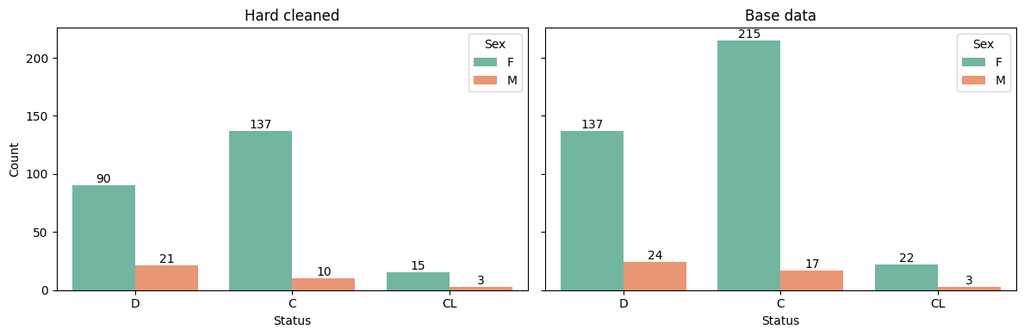

```python
fig, axes = plt.subplots(1, 2, figsize=(12, 4), sharey=True)

sns.countplot(data=df_cleaned_more, x='Status', ax=axes[0], palette='Set2', hue = 'Sex')
axes[0].set_title('Hard cleaned')
axes[0].set_xlabel('Status')
axes[0].set_ylabel('Count')

sns.countplot(data=df, x='Status', ax=axes[1], palette='Set2', hue = 'Sex')
axes[1].set_title('Base data')
axes[1].set_xlabel('Status')
axes[1].set_ylabel('')

for ax in axes:
    for container in ax.containers:
        ax.bar_label(container)

plt.tight_layout()
plt.show()
```

Co ciekawe model trenowany na bazowych danych poradził sobię ponad przeciętnie dobrze, idealnie klasyfikując wszystkich mężczyzn którzy znaleźli się w zbiorze testowym. Model trenowany na obciętym zbioreze danych poradził sobie trochę gorzej, jednak należy mieć na uwadzę, że liczba rekordów jest za mała, aby uznać to za rzetelny test modelu

# Wnioski Końcowe

Zbiór pacjentów okazał się dość ciężki do analizy, jednak nie ze względu na braki lub dystrybujce lecz rozmiar. 400 rekordów to absoulutnie mikroskopijny zbiór w porównaniu do standardowych zbiorów wykorzystywanych do ćwiczenia mechanizmów uczenia maszynowego. Dodatkowo ciężko jest wyciągać sensowne wnioski przez ilość rekordów np. sytuacje w których do zbioru testowego nie trafia żadna osoba os statusie CL.